# anharm

## Anharmonicity

### Computation of energy levels of the anharmonic oscillator and of its contribution to the vibrational Helmholtz function

With reference to the soft-mode driving the high temperature $\alpha-\beta$ transition in quartz, which is intrinsecally strongly anharmonic, the use of the program *anharm* will be here discussed.

The input required to run the program is summarized in the following:

- file **anharm_path.txt**: it must be present in the root folder (the one containing the program). The content of *anharm_path.txt* is the name of the folder containing the data (usually, the folder relative to the phase to be investigated). Such name is assigned to the *abs_path* variable;
- file **input_anharm.txt**: this file must be present in the folder specified in *anharm_path.txt*. The content of this file is:
  - folder name where SCAN data from CRYSTAL are stored (*path* variable);
  - output file name (it will be stored in the folder specified in the file *anharm_path.txt*);
  - minimim, maximum temperatures and number of points where the anharmonic Helmholtz function will be computed;
  - order of the power series used to fit the Helmholtz free energy as a function of V and T. The unit of the computed free energy is the hartree.

The output file contains the powers of the fitting polynomial together with the optimized coefficients for the reconstruction of the Helmholtz free energy as a function of V and T in the specified ranges. Volume ranges are from the input files found in the specified folder (*path* variable).

Files required to be found in the specified folder (*path* variable):

- **volumes.dat**: it contains the volumes at which the SCANMODE's where done together with the harmonic frequencies computed by CRYSTAL. If not both 0., the last two columns, specifies the minimum and maximum q's to select. Volumes of the primitive cell in cubic $\mathring{A}$; frequencies in $cm^{-1}$;
- **vect.dat**: eigenvectors of the normal mode: one column for each volume, in the same order as specified in the *volumes.dat* file;
- **input.txt**: it contains the names of the files where the Q-energies from the SCANMODE's are stored, as they are copied and pasted from the CRYSTAL output;
- **files** whose *names* are written in the *input.txt* file.

In the present case, the file **anharm_path.txt** file contains the folder name *quarzo_2020*.

The content of the file **input_anharm.txt** (in the *quarzo_2020* folder) is:

```
scan_a
anharm_a.dat
100 1100 24
4
```

This means that:

- the folder *quarzo_2020/scan_a* contains all the required input files;
- the output file will be *quarzo_2020/anharm_a.dat*;
- the Helmholtz function will be fitted on the 24 points in the $[100, 1100\,K]$ temperature range;
- the power of the *V*, *T* power serie is 4.

The **volumes.dat** file content (corresponding to 7 different data-sets, at different unit cell volumes, from the CRYSTAL/SCAN computations) is:

```
114.860943  215.6839  -8.   8.
109.884957  248.0118  -8.   8.
104.662515  274.6727  -8.   8.
97.900625   296.8036  -8.   8.
121.000240  161.2544  -6.   15.
124.910088  104.4002  -5.5  11.5
122.901896  138.5263  -5.5  13.5
```

The **input.txt** file content is:

```
scan_1.dat
scan_2.dat
scan_3.dat
scan_4.dat
scan_5.dat
scan_6.dat
scan_7.dat
```

The structure of each **scan_i.dat** file (in the example is the *scan_1.dat* file):

```
  -6.0000  -0.1318890832359E+04  -0.1318897402955E+04
  -5.6000  -0.1318894314601E+04  -0.1318899682885E+04
     .
     .

  11.6000  -0.1318885734175E+04  -0.1318848974101E+04
  12.0000  -0.1318884517817E+04  -0.1318844335623E+04
```

The columns of such file (copied and pasted from the CRYSTAL mail output file) are:

1. q value of the coordinate along the normal mode (in unit of $q_{max}$);
2. actual energy (hartree) computed by CRYSTAL at the specified q value;
3. energy (in hartree) computed in the limit of the harmonic approximation, from the harmonic $\omega$ frequency computed by CRYSTAL

The content of the **vect.dat** file is:

```
   0.0319  0.0348  0.0393  0.0461  0.0305  0.0338  0.0313
  -0.0184 -0.0201 -0.0227 -0.0266 -0.0176 -0.0195 -0.0181
   0.0000  0.0000  0.0000  0.0000  0.0000  0.0000  0.0000
   0.0000  0.0000  0.0000  0.0000  0.0000  0.0000  0.0000
   0.0368  0.0401  0.0454  0.0532  0.0353  0.0390  0.0362
   0.0000  0.0000  0.0000  0.0000  0.0000  0.0000  0.0000
  -0.0319 -0.0348 -0.0393 -0.0461 -0.0305 -0.0338 -0.0313
  -0.0184 -0.0201 -0.0227 -0.0266 -0.0176 -0.0195 -0.0181
   0.0000  0.0000  0.0000  0.0000  0.0000  0.0000  0.0000
  -0.0182 -0.0191 -0.0177 -0.0107 -0.0154 -0.0125 -0.0142
  -0.0527 -0.0483 -0.0446 -0.0398 -0.0618 -0.0772 -0.0669
   0.0391  0.0309  0.0215  0.0069  0.0514  0.0677  0.0569
   0.0547  0.0513  0.0475  0.0399  0.0612  0.0731  0.0650
   0.0106  0.0076  0.0070  0.0106  0.0175  0.0278  0.0212
   0.0391  0.0309  0.0215  0.0069  0.0514  0.0677  0.0569
  -0.0365 -0.0323 -0.0298 -0.0291 -0.0458 -0.0606 -0.0508
   0.0421  0.0407  0.0376  0.0292  0.0442  0.0494  0.0457
   0.0391  0.0309  0.0215  0.0069  0.0514  0.0677  0.0569
   0.0365  0.0323  0.0298  0.0291  0.0458  0.0606  0.0508
   0.0421  0.0407  0.0376  0.0292  0.0442  0.0494  0.0457
  -0.0391 -0.0309 -0.0215 -0.0069 -0.0514 -0.0677 -0.0569
   0.0182  0.0191  0.0177  0.0107  0.0154  0.0125  0.0142
  -0.0527 -0.0483 -0.0446 -0.0398 -0.0618 -0.0772 -0.0669
  -0.0391 -0.0309 -0.0215 -0.0069 -0.0514 -0.0677 -0.0569
  -0.0547 -0.0513 -0.0475 -0.0399 -0.0612 -0.0731 -0.0650
   0.0106  0.0076  0.0070  0.0106  0.0175  0.0278  0.0212
  -0.0391 -0.0309 -0.0215 -0.0069 -0.0514 -0.0677 -0.0569
```

Each column of the file (from the CRYSTAL main output file) represents the components of eigenvector (*normal mode*) considered, at a given unit cell volume. It is used to compute the value of the reduced mass of the mode, at each volume.

Let us load and run the program *anharm.py*:

```python
%matplotlib inline
%run anharm.py
```

```
Run time:  2021-05-07 11:22:49.523691
This is Anharm, version 1.1 - 16/07/2020

Basic usage: helm_fit()

Number of data SCAN's:   7:
Volumes: [114.860943 109.884957 104.662515  97.900625 121.00024  124.910088
 122.901896]
```

The program will immediately load all the input files except the *scan* data file. A list of the unit cell volumes considered is printed. The function **helm_fit()** will run the program and will produce the desired output (file *anharm_a.dat*); however one can also proceed step by step, as it will be shown in the following. At the step 1, the **set_up()** function is used:

```python
set_up()
```

**set_up** read all of the *scan* data files and saves all the relevant quantities in the array *anh*. Each element of such an array (the *anh* array is an instance of a class: the defined *anh_class*), one for each volume, has several attributes, for instance:

- *scan_name*: name of the scan file
- *vol*: unit cell volume
- *h_freq*: harmonic frequency
- *red*: reduced mass
- ..

For instance:

```python
anh[0].vol
```

```
114.860943
```

is the value of the unit cell volume (in $\mathring{A}^{3}$) corresponding to the first data set.

The **start_fit** function makes the *quartic* and the *quadratic* fit of the $E(q)$ curve numerically obtained by the CRYSTAL SCANMODE computation. The (mandatory) argument to the *start_fit* function is the *index* referring to the volume that has to be considered:

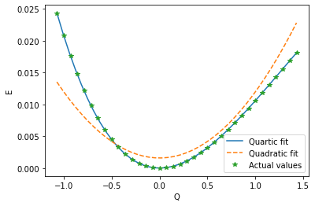

```python
start_fit(0)
```

Indeed, this is the fit corresponding to the volume stored in the variable anh[0].vol. The parameters resulting from such fit are stored in the anh[0].par variable:

```python
anh[0].par
```

```
array([ 2.17177972e-05,  1.52464168e-02, -5.10495380e-03,  4.45067540e-04])
```

Such parameters are then used to compute the matrix representation of the *anharmonic Hamiltonian* in the space of the eigenfunction of the harmonic oscillator (having anh[0].h_freq frequency). The **H matrix** is then diagonalized and its eigenvalues (sorted by value) are stored in the variable anh[0].vals. All this is performed by the **energy_anh** function which, once again, requires the *volume index* as mandatory argument:

```python
energy_anh(0)
```

The first 5 eigenvalues (energy in J) of such H_matrix are:

```python
anh[0].vals[0:5]
```

```
array([2.12667613e-21, 6.36466990e-21, 1.05794276e-20, 1.47705944e-20,
       1.89378012e-20])
```

The energy values ($\epsilon_i$) corresponding to the vibrational levels of the anharmonic oscillator are then used to numerically compute the partition function at a given temperature *T*:

$$ Z = \sum_{i=0}^N e^{-\epsilon_i/kT} $$

The number ($N$) of levels to be included depends upon the temperature and a check for the convergence of the $Z$ function against $N$ must be performed. The function **check_partition** is used for the purpose. The arguments of the function are the *volume index* and the temperature; for instance, for the volume we are considering, at T=1000 K:

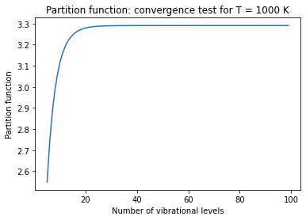

```
Threshold for convergence (on the variation of Z): 0.0050
Convergence reached at the  19 level
Minimum and maximum q values: -0.93, 1.36
```

```python
check_partition(0,1000)
```

That is: convercence is reached with 19 energy levels included in the calculation; the minimum and maximum *q* values (in unit of $q_{max}$) are -0.93, 1.36. As *qmax* is:

```python
anh[0].qmax
```

```
0.1785349265550021
```

this means that the corresponding *q* values, in the unit used in the *scan* data file, are:

```python
qmn=-0.93/anh[0].qmax
qmx=1.36/anh[0].qmax
print(qmn.round(2), qmx.round(2))
```

```
-5.21 7.62
```

To visualize the vibrational level structure (up the 19-th level), over the $E(q)$ curve plotted in the [qmn, qmx] range, the function **plot_levels** can be used. The (mandatory) arguments to the function are the *volume index* and the number of levels to be plotted. Optional arguments are *qmin* and *qmax* (if not specified, the whole *q* interval will be used).

[figure not shown]

```
Energy levels occupation (probabilities) at several
temperatures in the 300.0 -  1000.0 interval

 300.0   475.0   650.0   825.0   1000.0
   63.9    47.4    37.4    30.7    26.1
   23.0    24.8    23.3    21.2    19.2
    8.3    13.1    14.6    14.6    14.1
    3.0     6.9     9.1    10.1    10.4
    1.1     3.7     5.7     7.0     7.7
    0.4     1.9     3.6     4.9     5.7
    0.2     1.0     2.3     3.4     4.2
    0.1     0.6     1.4     2.4     3.2
    0.0     0.3     0.9     1.7     2.3
    0.0     0.2     0.6     1.2     1.8
    0.0     0.1     0.4     0.8     1.3
    0.0     0.0     0.2     0.6     1.0
    0.0     0.0     0.2     0.4     0.7
    0.0     0.0     0.1     0.3     0.6
    0.0     0.0     0.1     0.2     0.4
    0.0     0.0     0.0     0.1     0.3
    0.0     0.0     0.0     0.1     0.2
    0.0     0.0     0.0     0.1     0.2
    0.0     0.0     0.0     0.1     0.1
```

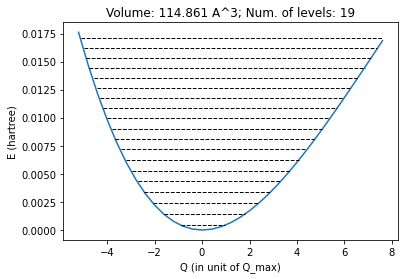

```python
plot_levels(0, 19, qmin=qmn, qmax=qmx)
```

A table with *occupation values* (*probability of occupation*) of each vibrational level against the temperature is also printed.

At an higher cell volume, more levels are required to reach convergence:

```python
v_index=5
print("Volume: %4.3f (A3)" % anh[v_index].vol)
```

```
Volume: 124.910 (A3)
```

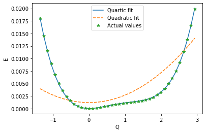

```python
start_fit(v_index)
```

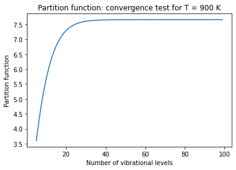

```
Threshold for convergence (on the variation of Z): 0.0050
Convergence reached at the  34 level
Minimum and maximum q values: -1.26, 2.73
```

```python
energy_anh(v_index)
check_partition(v_index, 900)
```

In order to

- compute the partition function and the Helmholtz free energy ($F$) values on the *V*, *T* grid defined by the input list of volumes and the temperature list, also specified in input
- fit the power series, up to the specified degree, to the numerically computed $F(V,T)$ values

the function **helm_fit** can be used. The (optional) argument given is the temperature at which the convergence of the $Z$ function is checked. **helm_fit** will perform all the required $E(q)$ fits; computes the vibrational energies as eigenvalues of the **H matrix**; computes the $F(V,T)$ values and eventually makes the $F$ fit.

```python
helm_fit(temp=900)
```

The file *anharm_a.dat* does contains the parameters of such a fit:

```
0 0   -1.3161037711227497
0 1   0.0002901312706983102
1 0   0.04826796015579944
0 2   8.331363275061264e-09
1 1   -8.607400365677583e-06
2 0   -0.0006613495408658537
0 3   2.073483891555499e-12
1 2   -2.465509273634077e-10
2 1   8.522339541870452e-08
3 0   4.014481368419415e-06
0 4   -1.6198649836458328e-15
1 3   3.242965795628521e-14
2 2   7.877944085208924e-13
3 1   -2.802389398877478e-10
4 0   -9.110525332100122e-09
END
```

This file can be used as input to the program computing the thermodynamics of the considered phase.

## How to make use of the anharmonic correction in the main program for the computation of the EoS, and other thermodynamic properties

In order to use the *anharm_a.dat* file to perform the anharmonic correction in the main *bm3_thermal* program, you should insert the ANH keyword in the input file (*input.txt*) of the main program; the keyword must be followed by an integer number that specifies the number of modes corrected for anharmonicity and, for each mode,

- the mode number;
- the *Brillouin flag* (BF): if it is an *optical* mode (BF=0) or an *off-center* vibrational mode (BF=1; computed by the supercell approach);
- the degeneracy of the mode.

Here is the example for quartz where three anharmonic modes were taken into account (modes n. 0, 8 and 4). The mode 4 is an off-center one (BF=1). Mode 8 is degenerate (its multiciplicity is equal to 2).

```
ANH
3
0 0 1
8 0 2
4 1 1
```

#### File structure

The file name *anharm_a.dat* must be written in the *anh.txt* file, which is read by the *bm3_thermal_2* program; *such file must be present in the folder containing the data of the considered phase.*

In the *main folder* (the one containing the *bm3_thermal_2* program), the file *anharm_path.txt* must be present and it should contain the name of the folder referring to the considered phase.

In the example of quartz, three *anharm* files are produced (e.g. *anharm_a.dat*, *anharm_b.dat*, *anharm_c.dat*), one for each anharmonic mode. Such three names must be written in the *anh.txt* in the *quartz* folder.